# Pollen Germination and Microbe Treatment

Chueh-Ju Kuo and Chelsea Ha

2026-03-18

## Load the libraries and data

```r
library("tidyverse")
library("janitor")
library("naniar")
library("ggthemes")
library("RColorBrewer")
library("paletteer")
library("shinythemes")
library(shinydashboard)
df <- read_csv("../Data/pollen_microbe_data.csv")
```

## Contents of the Project:

## Todo List

1. Jenny - Clean Data
   - make nice names with underscores
   - change the ns (not significant) to NA so that we can use naniar to visualize missing data and also so that it doesn’t mess with our graphs.
2. Jenny - Introduction - what is our research topic? List ideas below:
   - pollen germination and bursting across different microbial treatments and how this affects the microbial density
3. Chelsea/Jenny - Methods - how will we analyze
   - use tidyverse to clean data and make graphs, use shiny to make an interactive app to explore the data
4. Chelsea - Visuals - graphs, what are our key variables?
   - microbe treatment, time point, proportion germinated, proportion burst, microbial density
   - Shiny App
5. Chelsea - Conclusion:
   - summarize what we found and how it relates to the research question.
   - future directions: what are some next steps we can take to further explore this topic?
6. Organize Repository (going off the example given, but we can refine)
   - datasets folder
   - background info folder - need to check if we have any
   - shiny app folder
   - exploring data
   - graphs

## Data Exploration for each dataset

## Data on pollen germination and bursting with different microbial treatments (Jenny)

```r
pollen_microbe<-read_csv("../Data/pollen_microbe_data.csv")%>%
  clean_names()%>%
  rename(microbe_treatment = microbetreatment) %>%
  mutate(across(where(is.numeric), ~replace_na(., 0)))
pollen_microbe%>%
  distinct(microbe_group, microbe_treatment)
```

```
## # A tibble: 8 × 2
##   microbe_group           microbe_treatment
##   <chr>                   <chr>
## 1 Acinetobacter           362
## 2 Acinetobacter           4422
## 3 Acinetobacter           474
## 4 Acinetobacter           477
## 5 Yeast from nectar       52
## 6 No microbes             ctrl
## 7 Control pectin degrader pcaro
## 8 Acinetobacter           A.apis
```

Arrange the data from the most germinated to the least germinated for each time point and microbe treatment

```r
pollen_microbe %>%
  select(timepoint, microbe_group, microbe_treatment, allgerm) %>%
  arrange(desc(allgerm))
```

```
## # A tibble: 558 × 4
##    timepoint microbe_group microbe_treatment allgerm
##        <dbl> <chr>         <chr>               <dbl>
##  1        90 Acinetobacter 4422                0.903
##  2        90 Acinetobacter 4422                0.848
##  3        45 Acinetobacter 4422                0.839
##  4        45 Acinetobacter 4422                0.813
##  5        90 Acinetobacter 362                 0.778
##  6        45 Acinetobacter 4422                0.75
##  7        45 Acinetobacter 4422                0.745
##  8        90 Acinetobacter 477                 0.733
##  9        90 Acinetobacter 362                 0.706
## 10        90 No microbes   ctrl                0.7
## # ℹ 548 more rows
```

```r
#theme and colors
colors <- paletteer::palettes_d_names
my_palette <- paletteer_d("LaCroixColoR::Tangerine")
my_cols <- c("#f8e308",
             "#f9b80a",
             "#fc750d",
             "#ff2f11",
             "#b30c0c")
```

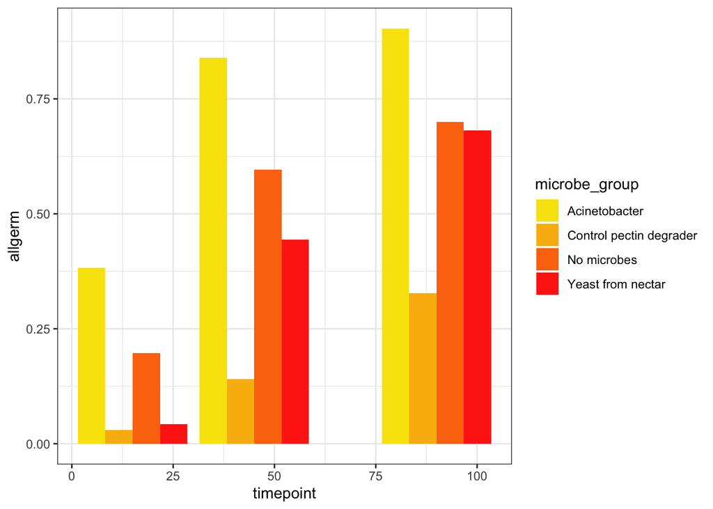

```r
pollen_microbe %>%
  group_by(timepoint, microbe_group) %>%
  ggplot(aes(x = timepoint, y = allgerm, fill = microbe_group))+
  geom_col(position = "dodge")+
  theme_bw()+
  scale_fill_manual(values=my_cols)
```

The acinetobacter has the largest amount of germination at each timepoint, followed by the control, then the yeast. The control pectin degrader was used to rule out the idea that simply breaking open the pollen (by degrading pectin in the inner layer of the pollen grain) would result in germination; we can see that the control pectin degrader has very low germination, so we can rule out that idea. The acinetobacter treatment has the highest germination, which suggests that the acinetobacter is inducing germination.

“Evidence presented here—including minimal effects of Pectobacterium, a known pectinase producer, and a lack of detected pectinase activity by Acinetobacter—suggest that pectinases alone are not responsible for the germination or bursting phenotype.”

We can see if the type of microbial group has any correlation with the number of germinated pollen (pollen tubes are fully grown), the number of grains that burst (pollen tubes are not fully grown and the pollen grain is broken), and the number of grains that burst at the tip.

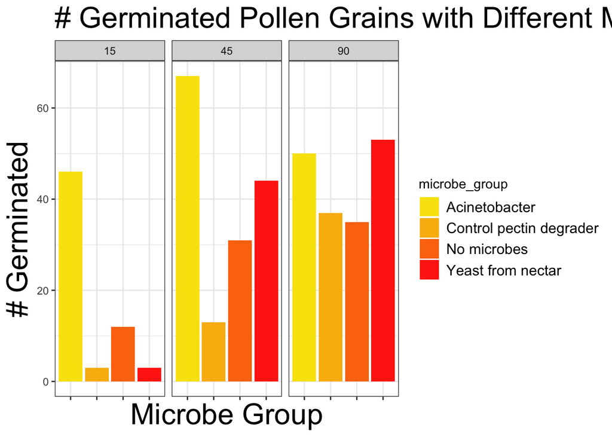

```r
pollen_microbe %>%
  group_by(microbe_group, timepoint) %>%
  ggplot(aes(x = microbe_group, y = number_germ, fill = microbe_group))+
  geom_col(position = "dodge")+
  theme_bw()+
  labs(x = "Microbe Group",
       y = "# Germinated",
       title="# Germinated Pollen Grains with Different Microbial Groups Over Time")+
  facet_wrap(~timepoint)+
  theme(axis.text.x = element_blank(),
        axis.title= element_text(size=24),
        plot.title= element_text(size=24),
        legend.text = element_text(size=12))+
  scale_fill_manual(values=my_cols)
```

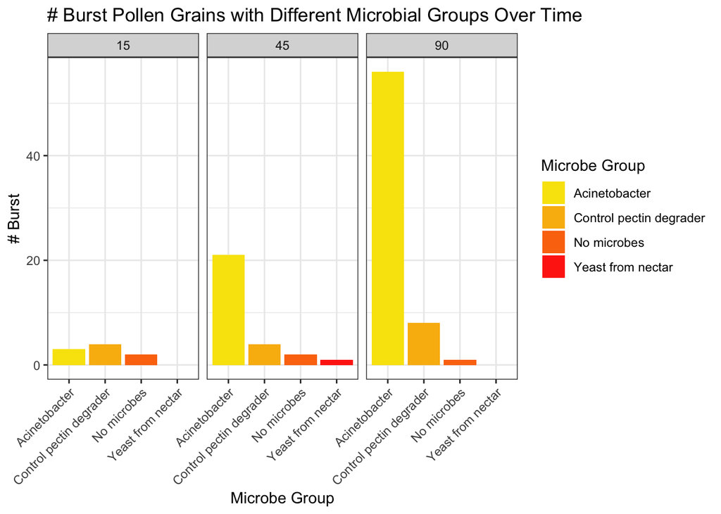

```r
pollen_microbe %>%
  group_by(microbe_group, timepoint) %>%
  ggplot(aes(x = microbe_group, y = number_burst, fill = microbe_group))+
  geom_col(position = "dodge")+
  theme_bw()+
  labs(x = "Microbe Group", y = "# Burst", fill = "Microbe Group", title="# Burst Pollen Grains with Different Microbial Groups Over Time")+
  facet_wrap(~timepoint)+
  theme(axis.text.x = element_text(angle =  45, hjust=1))+
  scale_fill_manual(values=my_cols)
```

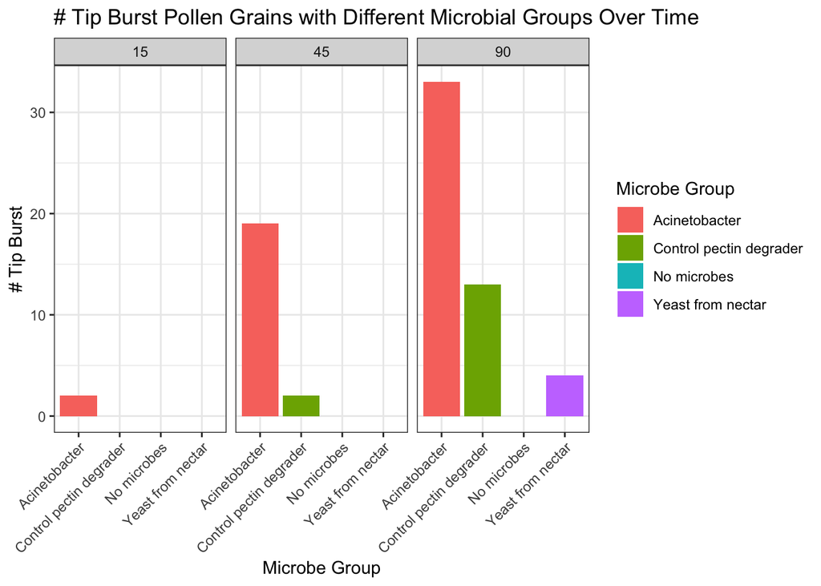

```r
pollen_microbe %>%
  group_by(microbe_group, timepoint) %>%
  ggplot(aes(x = microbe_group, y = number_tip_burst, fill = microbe_group))+
  geom_col(position = "dodge")+
  theme_bw()+
  labs(x = "Microbe Group", y = "# Tip Burst", fill = "Microbe Group", title="# Tip Burst Pollen Grains with Different Microbial Groups Over Time")+
  facet_wrap(~timepoint)+
  theme(axis.text.x = element_text(angle = 45, hjust=1))
```

## Data on proportion of grains germinated with different dilutions of A. pollinisSCC477 over time. (Jenny)

```r
dose_dependence <-read_csv("../Data/dose_dependence_data.csv")%>%
  clean_names() %>%
  rename(microbe_treatment = microbetreatment)
dose_dependence <- dose_dependence %>%
  mutate(time_minutes=case_when(
    timepoint=="15m" ~ 15,
           timepoint=="45m" ~ 45,
           timepoint=="90m" ~ 90,
           timepoint=="3h"  ~ 180,
           timepoint=="4h"  ~ 240,
           timepoint=="6h"  ~ 360,
           timepoint=="12h" ~ 720,
           timepoint=="24h" ~ 1440))
```

```r
glimpse(dose_dependence)
```

```
## Rows: 168
## Columns: 17
## $ trial_date            <chr> "01.16.20", "01.16.20", "01.16.20", "01.16.20", …
## $ image_id              <chr> "a1", "a2", "a3", "b1", "b2", "b3", "c1", "c2", …
## $ microbe_treatment     <chr> "(undiluted)", "(undiluted)", "(undiluted)", "(1…
## $ assay_replicate       <dbl> 1, 2, 3, 1, 2, 3, 1, 2, 3, 1, 2, 3, 1, 2, 3, 1, …
## $ timepoint             <chr> "15m", "15m", "15m", "15m", "15m", "15m", "15m",…
## $ minutes               <dbl> 15, 15, 15, 15, 15, 15, 15, 15, 15, 15, 15, 15, …
## $ initial_od            <dbl> 0.10000000, 0.10000000, 0.10000000, 0.05000000, …
## $ total_pollen          <dbl> 24, 23, 21, 20, 27, 26, 23, 21, 19, 39, 39, 24, …
## $ number_germ           <dbl> 0, 0, 0, 1, 0, 1, 0, 0, 0, 0, 0, 0, 0, 0, 0, 0, …
## $ number_burst          <dbl> 1, 0, 0, 1, 0, 0, 0, 0, 0, 0, 1, 0, 1, 0, 0, 0, …
## $ number_tip_burst      <dbl> 0, 0, 0, 0, 0, 0, 0, 0, 0, 0, 0, 0, 0, 0, 0, 0, …
## $ proportion_germinated <dbl> 0.00000000, 0.00000000, 0.00000000, 0.05000000, …
## $ proportion_burst      <dbl> 0.04166667, 0.00000000, 0.00000000, 0.05000000, …
## $ proportion_tip_burst  <dbl> 0.00000000, 0.00000000, 0.00000000, 0.00000000, …
## $ allgerm               <dbl> 0.00000000, 0.00000000, 0.00000000, 0.05000000, …
## $ allburst              <dbl> 0.04166667, 0.00000000, 0.00000000, 0.05000000, …
## $ time_minutes          <dbl> 15, 15, 15, 15, 15, 15, 15, 15, 15, 15, 15, 15, …
```

## graph of microbe treatment(dilution) vs. proportion germinated

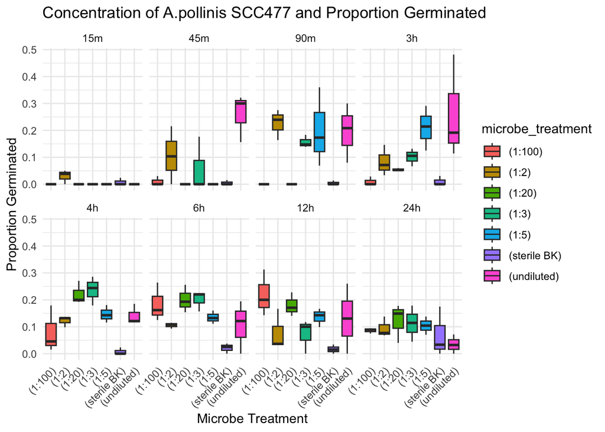

```r
dose_dependence%>%
  mutate(timepoint=factor(timepoint,
         levels=c("15m","45m","90m","3h","4h","6h","12h","24h")))%>%
  ggplot(aes(x=microbe_treatment,
             y=proportion_germinated,
             fill=microbe_treatment))+
  geom_boxplot()+
  facet_wrap(~timepoint, nrow=2)+
  theme_minimal()+
  labs(title="Concentration of A.pollinis SCC477 and Proportion Germinated",
       x="Microbe Treatment",
       y="Proportion Germinated")+
  theme(axis.text.x=element_text(angle=45, hjust=1))
```

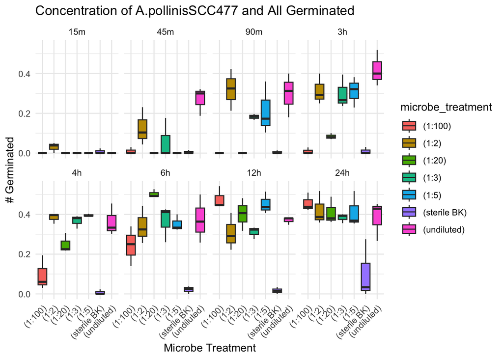

```r
dose_dependence %>%
  mutate(timepoint=factor(timepoint,
         levels=c("15m","45m","90m","3h","4h","6h","12h","24h")))%>%
  ggplot(aes(x=microbe_treatment,
             y=allgerm,
             fill=microbe_treatment))+
  geom_boxplot()+
  facet_wrap(~timepoint, nrow=2)+
  labs(title="Concentration of A.pollinisSCC477 and All Germinated",
       x="Microbe Treatment",
       y="# Germinated")+
  theme_minimal()+
  theme(axis.text.x=element_text(angle=45, hjust=1))
```

## Data on microbial hemocytometer counts of A. pollinis, when provided different pollen treatments. (Chelsea)

```r
a_pollinis <- read_csv("../Data/Apollinis_benefit_data.csv") %>%
  clean_names()
glimpse(a_pollinis)
```

```
## Rows: 45
## Columns: 5
## $ treatment_l     <chr> "FP+A.pollinis", "FP+A.pollinis", "FP+A.pollinis", "FP…
## $ tube            <chr> "A1", "A2", "A3", "B1", "B2", "B3", "C1", "C2", "C3", …
## $ initial_count   <dbl> 59062500, 55625000, 50312500, 4687500, 2812500, 437500…
## $ final_count_24h <dbl> 534375000, 584375000, 559375000, 9375000, 18750000, 93…
## $ date            <chr> "7.9.20", "7.9.20", "7.9.20", "7.9.20", "7.9.20", "7.9…
```

```r
a_pollinis %>%
  select(date, tube, treatment_l, final_count_24h, initial_count) %>%
  group_by(date, tube, treatment_l) %>%
  summarise(mean_delta=mean(final_count_24h - initial_count, na.rm = TRUE)) %>%
  arrange(desc(mean_delta))
```

[output not shown]

```
## # A tibble: 45 × 4
## # Groups:   date, tube [45]
##    date    tube  treatment_l   mean_delta
##    <chr>   <chr> <chr>              <dbl>
##  1 7.9.20  A2    FP+A.pollinis  528750000
##  2 7.9.20  A3    FP+A.pollinis  509062500
##  3 7.24.20 A2    FP+A.pollinis  479062500
##  4 7.9.20  A1    FP+A.pollinis  475312500
##  5 7.24.20 A3    FP+A.pollinis  462187500
##  6 7.24.20 A1    FP+A.pollinis  367812500
##  7 6.25.20 A1    FP+A.pollinis  357500000
##  8 7.9.20  C2    UP+A.pollinis  310000000
##  9 7.24.20 B1    FP alone       288125000
## 10 6.25.20 A3    FP+A.pollinis  267500000
## # ℹ 35 more rows
```

FP (fresh pollen) + A.pollinis had the greatest change in microbial density. This suggests that the presence of pollen may increase microbial growth, and that the type of pollen may also have an effect on microbial growth. The FP pollen treatment may provide more nutrients for microbial growth compared to the FP alone (pollen by itself) UP (ungerminable pollen) treatments without the A.pollinis bacteria, which could explain the greater increase in microbial density observed in the FP treatment.

## Data on microbial hemocytometer counts of M. reukaufii, when provided different pollen treatments. (Chelsea)

```r
yeast_benefit <- read_csv("../Data/yeast_benefit_data.csv") %>%
  clean_names()
yeast_benefit %>%
  select(date, treatment_l, final_count_24h, initial_count) %>%
  group_by(date, treatment_l) %>%
  summarise(mean_delta=mean(final_count_24h - initial_count, na.rm = TRUE)) %>%
  arrange(desc(mean_delta))
```

[output not shown]

```
## # A tibble: 15 × 3
## # Groups:   date [3]
##    date    treatment_l        mean_delta
##    <chr>   <chr>                   <dbl>
##  1 7.21.20 FP+ M. reukaufii   153437500
##  2 7.21.20 UP+ M.reukaufii    150312500
##  3 8.7.20  UP+ M.reukaufii     66666667.
##  4 9.2.20  UP+ M.reukaufii     65833333.
##  5 8.7.20  FP+ M. reukaufii    64687500
##  6 9.2.20  FP+ M. reukaufii    63500000
##  7 7.21.20 FP alone            31145833.
##  8 7.21.20 M. reukaufii alone  11041667.
##  9 9.2.20  M. reukaufii alone  10583333.
## 10 8.7.20  FP alone             6354167.
## 11 9.2.20  UP alone             3833333.
## 12 7.21.20 UP alone             3437500
## 13 9.2.20  FP alone             2166667.
## 14 8.7.20  M. reukaufii alone   -729167.
## 15 8.7.20  UP alone            -2500000
```

This table shows that the FP (fresh pollen) + yeast treatment had the greatest change in microbial density followed by the yeast with ungerminable or fresh pollen. We can infer that with pollen, the yeast will have more nutrients to grow, and that the type of pollen may also have an effect on microbial growth. The FP pollen treatment may provide more nutrients for microbial growth.

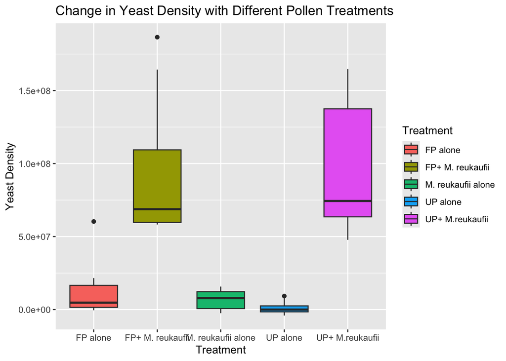

```r
yeast_benefit %>%
  ggplot(aes(x = treatment_l, y = final_count_24h - initial_count, fill = treatment_l)) +
  geom_boxplot()+
  labs(x = "Treatment", y = "Yeast Density", fill = "Treatment", title="Change in Yeast Density with Different Pollen Treatments")
```

## Data on germination and bursting after pollen (germinable or ungerminable) exposure to SCC477 (or no inoculation). (Chelsea)

```r
germination_burst <- read_csv("../Data/germ_AN.csv") %>%
  clean_names() %>%
  rename(pollen_treatment = pollentreatment)
```

Out of all the germinable pollen treatments, which had the most germination and bursting?

```r
germination_burst %>%
  filter(pollen_treatment=="GP" & timepoint== "24h") %>%
  arrange(desc(germ))
```

```
## # A tibble: 22 × 11
##    treatment pollen_treatment timepoint image_name total burst  germ tipburst
##    <chr>     <chr>            <chr>     <chr>      <dbl> <dbl> <dbl>    <dbl>
##  1 477_GP    GP               24h       A4           112     1    56        1
##  2 477_GP    GP               24h       A1           132     1    43        2
##  3 477_GP    GP               24h       A3           105     1    41        0
##  4 477_GP    GP               24h       A2           138     2    40        0
##  5 477_GP    GP               24h       A3           103     0    40        2
##  6 477_GP    GP               24h       A4            63     0    39        0
##  7 477_GP    GP               24h       C1           156     2    37        4
##  8 477_GP    GP               24h       A2           100     0    35        1
##  9 477_GP    GP               24h       A1           204     3    33        1
## 10 477_GP    GP               24h       A1            89     0    32        0
## # ℹ 12 more rows
## # ℹ 3 more variables: allgerm <dbl>, allburst <dbl>, date <chr>
```

We can see that the germinable pollen with SCC477 had the most germination and bursting, which suggests that the presence of SCC477 may induce germination and bursting in pollen. The control treatments without SCC477 had very low germination and bursting, which suggests that the presence of SCC477 may be necessary for inducing germination and bursting in pollen.

## Data on protein in solution after pollen (germinable or ungerminable or no pollen) exposure to SCC477 (or no inoculation). (Chelsea)

```r
protein_density <- read_csv("../Data/Lowry_data1.csv") %>%
  clean_names() %>%
  rename(pollen_treatment = pollentreatment,
         microbe_treatment = microbetreatment)
protein_density %>%
  filter(pollen_treatment=="Fresh" & date=="3.29.21") %>%
  group_by(microbe_treatment) %>%
  arrange(desc(protein))
```

```
## # A tibble: 6 × 9
## # Groups:   microbe_treatment [2]
##   row   column timepoint well_id protein treatment     microbe_treatment
##   <chr>  <dbl> <chr>     <chr>     <dbl> <chr>         <chr>
## 1 C          1 T24       C1        3863. 30_477_Fresh  30_477
## 2 B          1 T24       B1        3843. 30_477_Fresh  30_477
## 3 A          1 T24       A1        2447. 30_477_Fresh  30_477
## 4 C          5 T24       C5         908. 30_ctrl_Fresh 30_ctrl
## 5 B          5 T24       B5         657. 30_ctrl_Fresh 30_ctrl
## 6 A          5 T24       A5         483. 30_ctrl_Fresh 30_ctrl
## # ℹ 2 more variables: pollen_treatment <chr>, date <chr>
```

```r
protein_density %>%
  filter(pollen_treatment=="Ungerm" & date== "4.12.21") %>%
  group_by(microbe_treatment) %>%
  arrange(desc(protein))
```

```
## # A tibble: 16 × 9
## # Groups:   microbe_treatment [2]
##    row   column timepoint well_id protein treatment      microbe_treatment
##    <chr>  <dbl> <chr>     <chr>     <dbl> <chr>          <chr>
##  1 A          5 T24       A5        1971. 30_477_Ungerm  30_477
##  2 A          6 T24       A6        1813. 30_477_Ungerm  30_477
##  3 A          7 T24       A7        1765. 30_477_Ungerm  30_477
##  4 A          8 T24       A8        1456. 30_477_Ungerm  30_477
##  5 E          8 T24       E8        1363. 30_ctrl_Ungerm 30_ctrl
##  6 E          6 T24       E6        1235. 30_ctrl_Ungerm 30_ctrl
##  7 A          8 T0        A8        1221. 30_477_Ungerm  30_477
##  8 E          5 T24       E5        1200. 30_ctrl_Ungerm 30_ctrl
##  9 E          7 T24       E7        1154. 30_ctrl_Ungerm 30_ctrl
## 10 E          6 T0        E6        1059. 30_ctrl_Ungerm 30_ctrl
## 11 E          8 T0        E8         980. 30_ctrl_Ungerm 30_ctrl
## 12 E          7 T0        E7         971. 30_ctrl_Ungerm 30_ctrl
## 13 A          6 T0        A6         942. 30_477_Ungerm  30_477
## 14 A          7 T0        A7         875. 30_477_Ungerm  30_477
## 15 A          5 T0        A5         726. 30_477_Ungerm  30_477
## 16 E          5 T0        E5         645. 30_ctrl_Ungerm 30_ctrl
## # ℹ 2 more variables: pollen_treatment <chr>, date <chr>
```

This table shows protein concentrations from ungerminated pollen samples with different microbial treatments. The data suggest that microbial presence, particularly A. pollinis, may increase the amount of protein released from pollen over time.

## Questions + Graphs for Presentation:

```r
ls("package:ggthemes")[grepl("theme_", ls("package:ggthemes"))]
```

```
##  [1] "theme_base"            "theme_calc"            "theme_clean"
##  [4] "theme_economist"       "theme_economist_white" "theme_excel"
##  [7] "theme_excel_new"       "theme_few"             "theme_fivethirtyeight"
## [10] "theme_foundation"      "theme_gdocs"           "theme_hc"
## [13] "theme_igray"           "theme_map"             "theme_pander"
## [16] "theme_par"             "theme_solarized"       "theme_solarized_2"
## [19] "theme_solid"           "theme_stata"           "theme_tufte"
## [22] "theme_wsj"
```

[output not shown]

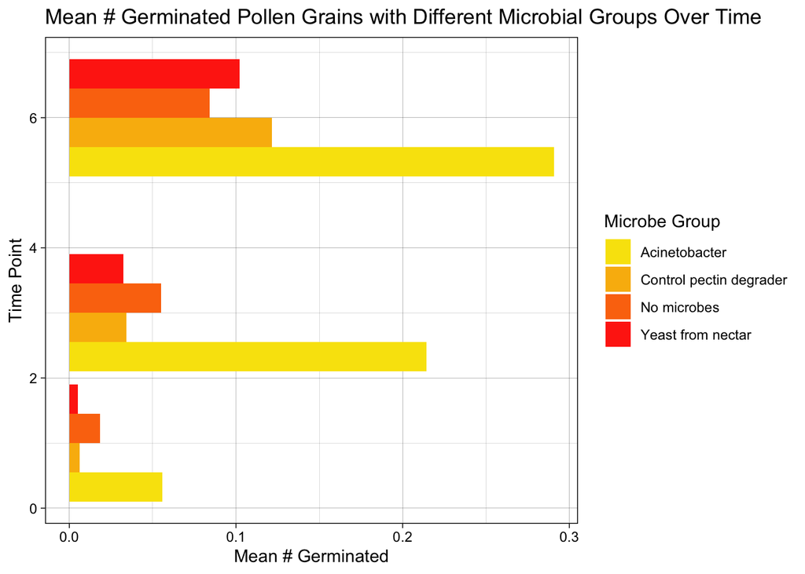

```r
pollen_microbe %>%
  group_by(microbe_group, timepoint) %>%
  summarise(mean_germinated = mean(allgerm)) %>%
  ggplot(aes(x = timepoint/15, y = mean_germinated, fill = microbe_group))+
  geom_col(position = "dodge")+
  coord_flip()+
  labs(x = "Time Point",
       y = "Mean # Germinated", fill = "Microbe Group",
       title="Mean # Germinated Pollen Grains with Different Microbial Groups Over Time")+
theme_tufte()+
  theme_linedraw()+
  scale_fill_manual(values=my_cols)
```

## 2) How does the microbial density change with different pollen conditions? (Relationship between bacterial density and pollen germination) (Jenny)

[output not shown]

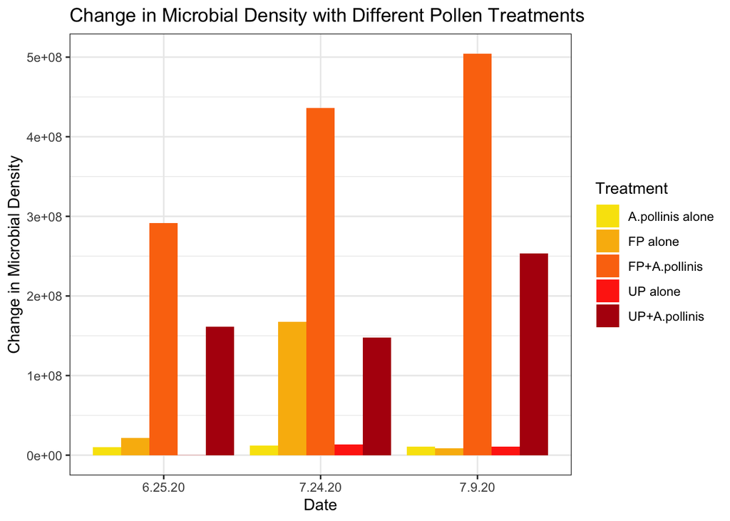

```r
a_pollinis %>%
  group_by(date, treatment_l) %>%
  summarise(mean_delta = mean(final_count_24h - initial_count, na.rm = TRUE)) %>%
  ggplot(aes(x = date, y = mean_delta, fill = treatment_l)) +
  geom_col(position = "dodge") +
  labs(x = "Date", y = "Change in Microbial Density", fill = "Treatment", title="Change in Microbial Density with Different Pollen Treatments")+
  theme_bw()+
  scale_fill_manual(values=my_cols)
```

## 3) Microbial growth with different pollen conditions (Jenny)

```r
a_pollinis_wide <- a_pollinis %>%
  group_by(date) %>%
  pivot_wider(
    names_from = tube,
    values_from = final_count_24h
  )
a_pollinis_wide
```

```
## # A tibble: 45 × 18
## # Groups:   date [3]
##    treatment_l   initial_count date          A1       A2      A3      B1      B2
##    <chr>                 <dbl> <chr>      <dbl>    <dbl>   <dbl>   <dbl>   <dbl>
##  1 FP+A.pollinis      59062500 7.9.20 534375000  NA      NA           NA NA
##  2 FP+A.pollinis      55625000 7.9.20        NA   5.84e8 NA           NA NA
##  3 FP+A.pollinis      50312500 7.9.20        NA  NA       5.59e8      NA NA
##  4 FP alone            4687500 7.9.20        NA  NA      NA      9375000 NA
##  5 FP alone            2812500 7.9.20        NA  NA      NA           NA  1.87e7
##  6 FP alone            4375000 7.9.20        NA  NA      NA           NA NA
##  7 UP+A.pollinis      66875000 7.9.20        NA  NA      NA           NA NA
##  8 UP+A.pollinis      61875000 7.9.20        NA  NA      NA           NA NA
##  9 UP+A.pollinis      52500000 7.9.20        NA  NA      NA           NA NA
## 10 UP alone            2812500 7.9.20        NA  NA      NA           NA NA
## # ℹ 35 more rows
## # ℹ 10 more variables: B3 <dbl>, C1 <dbl>, C2 <dbl>, C3 <dbl>, D1 <dbl>,
## #   D2 <dbl>, D3 <dbl>, E1 <dbl>, E2 <dbl>, E3 <dbl>
```

```r
a_pollinis <- a_pollinis %>%
  mutate(delta = final_count_24h - initial_count) %>%
  arrange(desc(delta))
a_pollinis
```

```
## # A tibble: 45 × 6
##    treatment_l   tube  initial_count final_count_24h date        delta
##    <chr>         <chr>         <dbl>           <dbl> <chr>       <dbl>
##  1 FP+A.pollinis A2         55625000       584375000 7.9.20  528750000
##  2 FP+A.pollinis A3         50312500       559375000 7.9.20  509062500
##  3 FP+A.pollinis A2         42812500       521875000 7.24.20 479062500
##  4 FP+A.pollinis A1         59062500       534375000 7.9.20  475312500
##  5 FP+A.pollinis A3         44062500       506250000 7.24.20 462187500
##  6 FP+A.pollinis A1         41562500       409375000 7.24.20 367812500
##  7 FP+A.pollinis A1         48750000       406250000 6.25.20 357500000
##  8 UP+A.pollinis C2         61875000       371875000 7.9.20  310000000
##  9 FP alone      B1         11875000       300000000 7.24.20 288125000
## 10 FP+A.pollinis A3         48125000       315625000 6.25.20 267500000
## # ℹ 35 more rows
```

```r
names(a_pollinis)
```

```
## [1] "treatment_l"     "tube"            "initial_count"   "final_count_24h"
## [5] "date"            "delta"
```

##Jenny

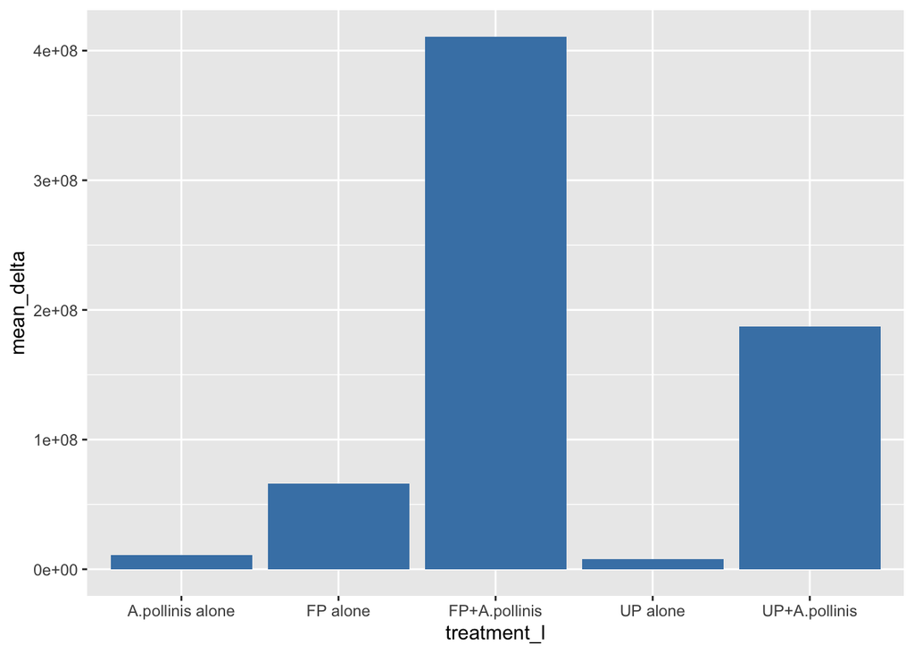

```r
a_pollinis %>%
  group_by(treatment_l) %>%
  summarise(mean_delta = mean(delta, na.rm = TRUE)) %>%
  ggplot(aes(x = treatment_l, y = mean_delta)) +
  geom_col(fill = "steelblue")
```

## 4) Does pollen germination increase microbial growth? (Chelsea)

[output not shown]

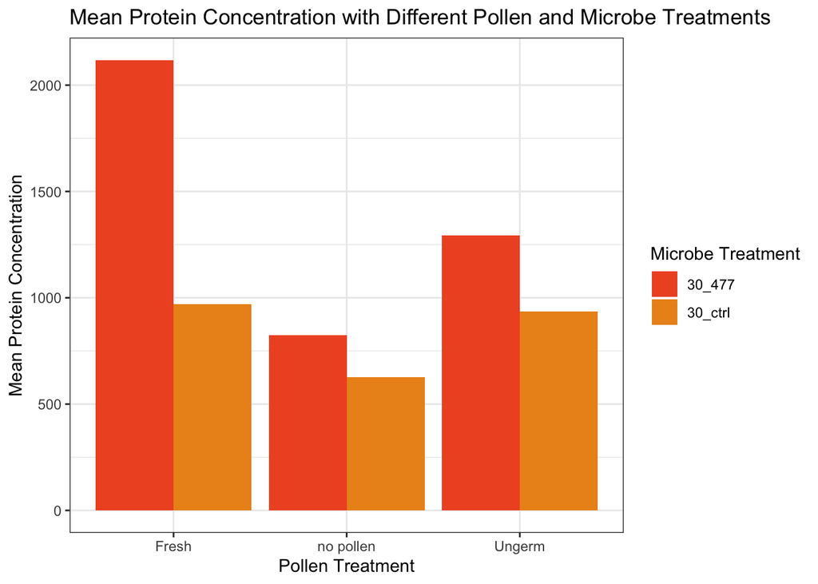

```r
protein_density%>%
  group_by(pollen_treatment, microbe_treatment) %>%
  summarise(mean_protein = mean(protein)) %>%
  ggplot(aes(x = pollen_treatment, y = mean_protein, fill = microbe_treatment))+
  geom_col(position = "dodge")+
  theme_bw()+
  labs(x = "Pollen Treatment", y = "Mean Protein Concentration", fill = "Microbe Treatment", title="Mean Protein Concentration with Different Pollen and Microbe Treatments")+
  theme_bw()+
  scale_fill_manual(values=my_palette)
```

- Build a shiny app that lets researchers see the effects of the microbial treatments on the stages of pollen (premature pollen, bursted pollen before germination, and germinated pollen that has bursted at the tip). Users can also choose whether the pollen is germinable or ungerminable.
- The app will show the number of pollen grains that are germinated, bursted before germination, and bursted at the tip for each microbial treatment and time point. This will allow researchers to easily see the effects of the microbial treatments on pollen germination and bursting.
- The app will also allow users to see the effects of different dilutions of A. pollinis SCC477 on pollen germination over time. This will allow researchers to see if there is a dose-dependent relationship between A. pollinis SCC477 and pollen germination.

```r
library(shiny)
library(tidyverse)
library(janitor)
library(shinythemes)

# --- Data Preparation ---
pollen_microbe <- read_csv("../Data/pollen_microbe_data.csv") %>%
  clean_names() %>%
  rename(microbe_treatment = microbetreatment) %>%
  mutate(across(where(is.numeric), ~replace_na(., 0)))

dose_dependence <- read_csv("../Data/dose_dependence_data.csv") %>%
  clean_names() %>%
  rename(microbe_treatment = microbetreatment)

protein_density <- read_csv("../Data/Lowry_data1.csv") %>%
  clean_names() %>%
  rename(pollen_treatment = pollentreatment, microbe_treatment = microbetreatment)

# --- Theme/Colors ---
orange_pal <- c("#f8e308", "#f9b80a", "#fc750d", "#ff2f11", "#b30c0c")

# --- UI ---
ui <- fluidPage(
  theme = shinytheme("spacelab"),
  tags$head(tags$style(HTML("
    body { background-color: #FFFFE0; color: black; }
    .well { background-color: #FFFACD; border-color: #F0E68C; }
  "))),

  titlePanel("Pollen-Microbe Interaction Dashboard"),

  sidebarLayout(
    sidebarPanel(
      h4("Global Filters"),
      selectInput("group_select", "1. Choose Microbe Group:",
                  choices = unique(pollen_microbe$microbe_group), selected = "Acinetobacter"),
      uiOutput("treatment_selector"),
      hr(),
      h4("Dose Analysis"),
      checkboxGroupInput("dose_select", "2. Select SCC477 Dilutions:",
                         choices = unique(dose_dependence$microbe_treatment),
                         selected = unique(dose_dependence$microbe_treatment)),
      hr(),
      h4("Recommendation:"),
      uiOutput("recommendation")
    ),

    mainPanel(
      tabsetPanel(
        tabPanel("Germination Explorer",
                 plotOutput("germ_plot"),
                 hr(),
                 plotOutput("dose_plot")),
        #
        # tabPanel("Protein vs Germination",
        #          h3("The 'Full Circle' Discovery"),
        #          plotOutput("protein_scatter_plot")),

        tabPanel("Quick Summary",
                 tableOutput("summary_table"))
      )
    )
  )
)

# --- Server ---
server <- function(input, output, session) {

  # Dynamic UI
  output$treatment_selector <- renderUI({
    available <- pollen_microbe %>% filter(microbe_group == input$group_select) %>% pull(microbe_treatment) %>% unique()
    checkboxGroupInput("treat_select", "Select Treatments:", choices = available, selected = available[1])
  })

  # Logic: Best Performer
  output$recommendation <- renderUI({
    best <- pollen_microbe %>%
      group_by(microbe_treatment) %>%
      summarise(avg = mean(allgerm, na.rm = TRUE)) %>%
      filter(avg == max(avg))

    div(style = "background-color: #ffcc00; padding: 10px; border-radius: 5px; color: black;",
        strong("Top Performer:"),
        paste(best$microbe_treatment, "(Avg:", round(best$avg, 2), ")")
    )
  })

  # Plot 1: Germination
  output$germ_plot <- renderPlot({
    req(input$treat_select)
    pollen_microbe %>% filter(microbe_group == input$group_select, microbe_treatment %in% input$treat_select) %>%
      ggplot(aes(x = microbe_treatment, y = allgerm, fill = microbe_treatment)) +
      geom_col(position = "dodge", color = "black") + facet_wrap(~timepoint) +
      scale_fill_manual(values = rep(orange_pal, length.out = 20)) +
      theme_minimal() + labs(title = "Total Germination", y = "Count")
  })

  # Plot 2: Dose Dependence
  output$dose_plot <- renderPlot({
    req(input$dose_select)
    dose_dependence %>% filter(microbe_treatment %in% input$dose_select) %>%
      ggplot(aes(x = microbe_treatment, y = proportion_germinated, fill = microbe_treatment)) +
      geom_boxplot(color = "black") + facet_wrap(~timepoint) +
      scale_fill_manual(values = rep(orange_pal, length.out = 20)) +
      theme_minimal() + labs(title = "Dose Dependence (SCC477)")
  })

  # # Plot 3: Protein Scatter
  # output$protein_scatter_plot <- renderPlot({
  #   plot_data <- protein_density %>%
  #     group_by(microbe_treatment) %>%
  #     summarise(mean_protein = mean(protein, na.rm = TRUE)) %>%
  #     inner_join(pollen_microbe %>%
  #                  group_by(microbe_treatment) %>%
  #                  summarise(mean_germ = mean(allgerm, na.rm = TRUE)),
  #                by = "microbe_treatment") %>%
  #
  #   ggplot(plot_data, aes(x = mean_protein, y = mean_germ, color = microbe_treatment)) +
  #     geom_point(size = 5) + geom_smooth(method = "lm", se = FALSE, color = "black", linetype = "dashed") +
  #     theme_minimal() + labs(title = "Protein Release vs. Germination Rate", x = "Mean Protein", y = "Mean Germination") +
  #     scale_color_manual(values = rep(orange_pal, length.out = 20))
  # })
  #
  # Table: Summary
  output$summary_table <- renderTable({
    pollen_microbe %>% group_by(microbe_group) %>%
      summarise(Avg_Germination = mean(allgerm)) %>% arrange(desc(Avg_Germination))
  })
}

shinyApp(ui, server)
```

## Exploration of Pollen Microbe Data (Jenny)

```r
glimpse(pollen_microbe)
```

```
## Rows: 558
## Columns: 15
## $ microbe_group         <chr> "Acinetobacter", "Acinetobacter", "Acinetobacter…
## $ microbe_treatment     <chr> "362", "362", "362", "4422", "4422", "4422", "47…
## $ trial_date            <chr> "05.09.2019", "05.09.2019", "05.09.2019", "05.09…
## $ assay_replicate       <dbl> 1, 2, 3, 1, 2, 3, 1, 2, 3, 1, 2, 3, 1, 2, 3, 1, …
## $ timepoint             <dbl> 15, 15, 15, 15, 15, 15, 15, 15, 15, 15, 15, 15, …
## $ standardized_od_plate <dbl> 0.05, 0.05, 0.05, 0.05, 0.05, 0.05, 0.05, 0.05, …
## $ total_pollen          <dbl> 73, 63, 95, 49, 97, 79, 107, 92, 92, 84, 66, 71,…
## $ number_germ           <dbl> 0, 1, 0, 11, 6, 1, 0, 0, 0, 0, 1, 1, 0, 0, 0, 0,…
## $ number_burst          <dbl> 0, 0, 0, 0, 1, 1, 0, 0, 0, 0, 0, 0, 0, 0, 0, 0, …
## $ number_tip_burst      <dbl> 0, 0, 0, 0, 0, 0, 0, 0, 0, 0, 0, 0, 0, 0, 0, 0, …
## $ prop_germ             <dbl> 0.000, 0.016, 0.000, 0.224, 0.062, 0.013, 0.000,…
## $ prop_burst            <dbl> 0.000, 0.000, 0.000, 0.000, 0.010, 0.013, 0.000,…
## $ prop_tip_burst        <dbl> 0, 0, 0, 0, 0, 0, 0, 0, 0, 0, 0, 0, 0, 0, 0, 0, …
## $ allgerm               <dbl> 0.000, 0.016, 0.000, 0.224, 0.062, 0.013, 0.000,…
## $ allburst              <dbl> 0.000, 0.000, 0.000, 0.000, 0.010, 0.013, 0.000,…
```

```r
summary(pollen_microbe)
```

```
##  microbe_group      microbe_treatment   trial_date        assay_replicate
##  Length:558         Length:558         Length:558         Min.   :0.000
##  Class :character   Class :character   Class :character   1st Qu.:1.000
##  Mode  :character   Mode  :character   Mode  :character   Median :2.000
##                                                           Mean   :2.195
##                                                           3rd Qu.:3.000
##                                                           Max.   :4.000
##    timepoint     standardized_od_plate  total_pollen     number_germ
##  Min.   :15.00   Min.   :0.02500       Min.   : 14.00   Min.   : 0.000
##  1st Qu.:15.00   1st Qu.:0.02500       1st Qu.: 40.00   1st Qu.: 0.000
##  Median :45.00   Median :0.02500       Median : 67.50   Median : 1.000
##  Mean   :50.32   Mean   :0.03575       Mean   : 73.62   Mean   : 7.423
##  3rd Qu.:90.00   3rd Qu.:0.05000       3rd Qu.:100.00   3rd Qu.:10.000
##  Max.   :90.00   Max.   :0.05000       Max.   :187.00   Max.   :67.000
##   number_burst     number_tip_burst   prop_germ         prop_burst
##  Min.   : 0.0000   Min.   : 0.000   Min.   :0.00000   Min.   :0.0000
##  1st Qu.: 0.0000   1st Qu.: 0.000   1st Qu.:0.00000   1st Qu.:0.0000
##  Median : 0.0000   Median : 0.000   Median :0.02839   Median :0.0000
##  Mean   : 0.7491   Mean   : 1.022   Mean   :0.11322   Mean   :0.0099
##  3rd Qu.: 0.0000   3rd Qu.: 0.000   3rd Qu.:0.16125   3rd Qu.:0.0000
##  Max.   :56.0000   Max.   :33.000   Max.   :0.87100   Max.   :0.3040
##  prop_tip_burst       allgerm          allburst
##  Min.   :0.00000   Min.   :0.0000   Min.   :0.00000
##  1st Qu.:0.00000   1st Qu.:0.0000   1st Qu.:0.00000
##  Median :0.00000   Median :0.0285   Median :0.00000
##  Mean   :0.01251   Mean   :0.1253   Mean   :0.02233
##  3rd Qu.:0.00000   3rd Qu.:0.1820   3rd Qu.:0.01400
##  Max.   :0.30300   Max.   :0.9030   Max.   :0.32600
```

distribution of microbe group (shows the number of samples for each microbe group, which is important to know for our analysis).

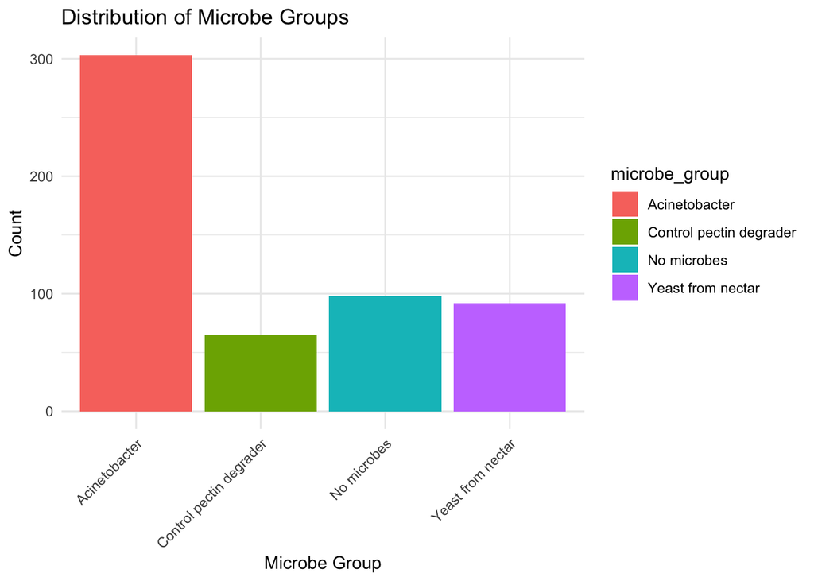

```r
pollen_microbe %>%
  ggplot(aes(x=microbe_group, fill=microbe_group))+
  geom_bar()+
  theme_minimal()+
  labs(
    title = "Distribution of Microbe Groups",
    x="Microbe Group",
    y="Count")+
  theme(axis.text.x=element_text(angle=45, hjust=1))
```

microbe group and all germination.

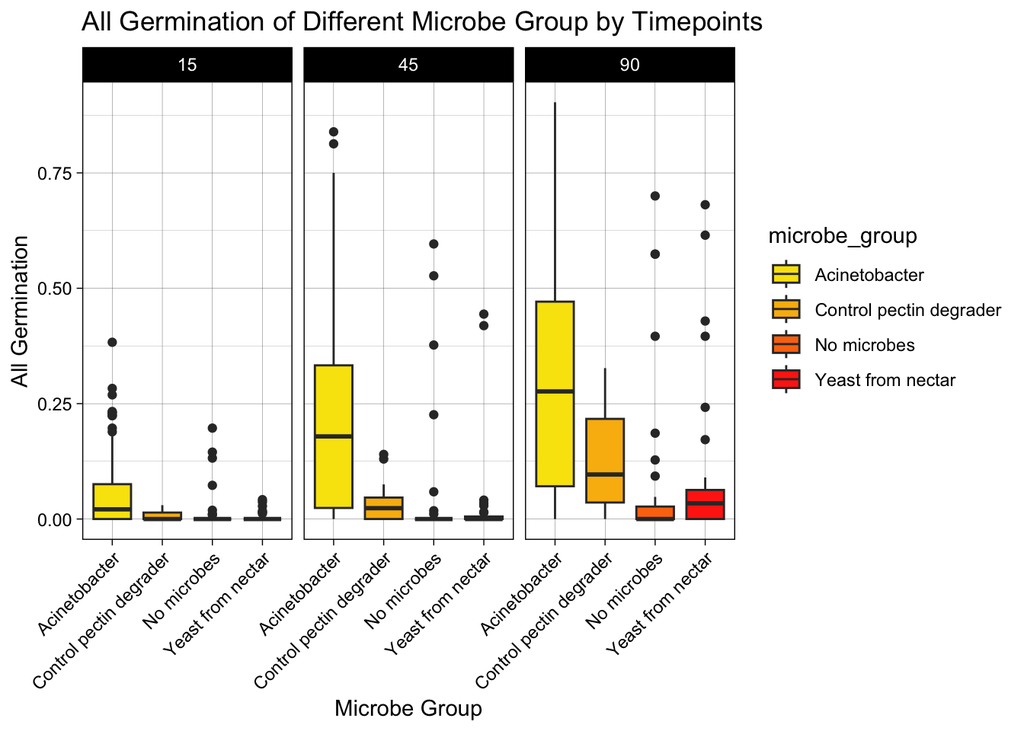

```r
pollen_microbe%>%
  ggplot(aes(x=microbe_group, y=allgerm, fill=microbe_group))+
  geom_boxplot()+
  facet_wrap(~timepoint)+
  theme_linedraw()+
  labs(
    title="All Germination of Different Microbe Group by Timepoints",
    x="Microbe Group",
    y="All Germination")+
  theme(axis.text.x = element_text(angle = 45, hjust = 1))+
  scale_fill_manual(values=my_cols)
```

germination and time.

[output not shown]

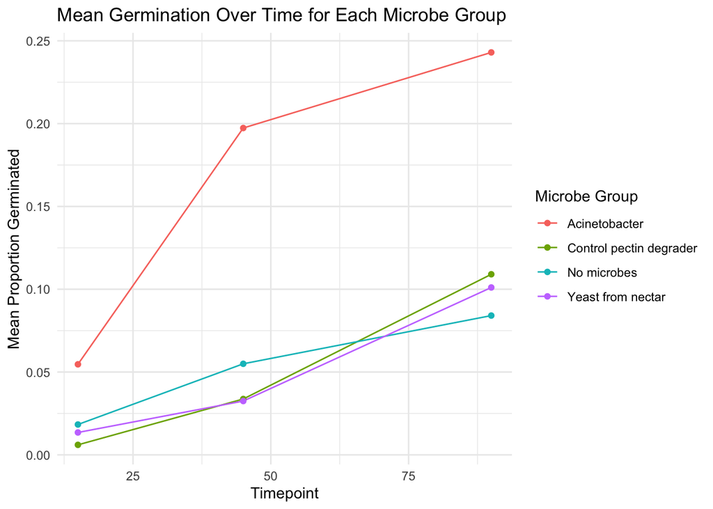

```r
pollen_microbe%>%
  group_by(microbe_group, timepoint)%>%
  summarize(mean_germ = mean(prop_germ, na.rm = TRUE)) %>%
  ggplot(aes(x=timepoint,
             y=mean_germ,
             color=microbe_group))+
  geom_line()+
  geom_point()+
  theme_minimal()+
  labs(
    title="Mean Germination Over Time for Each Microbe Group",
    x="Timepoint",
    y="Mean Proportion Germinated",
    color="Microbe Group")+
  scale_fill_manual(values=my_cols)
```

## Exploration of Dose Dependency Data (Jenny)

```r
glimpse(dose_dependence)
```

```
## Rows: 168
## Columns: 17
## $ trial_date            <chr> "01.16.20", "01.16.20", "01.16.20", "01.16.20", …
## $ image_id              <chr> "a1", "a2", "a3", "b1", "b2", "b3", "c1", "c2", …
## $ microbe_treatment     <chr> "(undiluted)", "(undiluted)", "(undiluted)", "(1…
## $ assay_replicate       <dbl> 1, 2, 3, 1, 2, 3, 1, 2, 3, 1, 2, 3, 1, 2, 3, 1, …
## $ timepoint             <chr> "15m", "15m", "15m", "15m", "15m", "15m", "15m",…
## $ minutes               <dbl> 15, 15, 15, 15, 15, 15, 15, 15, 15, 15, 15, 15, …
## $ initial_od            <dbl> 0.10000000, 0.10000000, 0.10000000, 0.05000000, …
## $ total_pollen          <dbl> 24, 23, 21, 20, 27, 26, 23, 21, 19, 39, 39, 24, …
## $ number_germ           <dbl> 0, 0, 0, 1, 0, 1, 0, 0, 0, 0, 0, 0, 0, 0, 0, 0, …
## $ number_burst          <dbl> 1, 0, 0, 1, 0, 0, 0, 0, 0, 0, 1, 0, 1, 0, 0, 0, …
## $ number_tip_burst      <dbl> 0, 0, 0, 0, 0, 0, 0, 0, 0, 0, 0, 0, 0, 0, 0, 0, …
## $ proportion_germinated <dbl> 0.00000000, 0.00000000, 0.00000000, 0.05000000, …
## $ proportion_burst      <dbl> 0.04166667, 0.00000000, 0.00000000, 0.05000000, …
## $ proportion_tip_burst  <dbl> 0.00000000, 0.00000000, 0.00000000, 0.00000000, …
## $ allgerm               <dbl> 0.00000000, 0.00000000, 0.00000000, 0.05000000, …
## $ allburst              <dbl> 0.04166667, 0.00000000, 0.00000000, 0.05000000, …
## $ time_minutes          <dbl> 15, 15, 15, 15, 15, 15, 15, 15, 15, 15, 15, 15, …
```

```r
summary(dose_dependence)
```

```
##   trial_date          image_id         microbe_treatment  assay_replicate
##  Length:168         Length:168         Length:168         Min.   :1
##  Class :character   Class :character   Class :character   1st Qu.:1
##  Mode  :character   Mode  :character   Mode  :character   Median :2
##                                                           Mean   :2
##                                                           3rd Qu.:3
##                                                           Max.   :3
##
##   timepoint            minutes          initial_od      total_pollen
##  Length:168         Min.   :  15.00   Min.   :0.0000   Min.   :11.00
##  Class :character   1st Qu.:  78.75   1st Qu.:0.0010   1st Qu.:33.00
##  Mode  :character   Median : 210.00   Median :0.0200   Median :43.00
##                     Mean   : 386.25   Mean   :0.0299   Mean   :45.35
##                     3rd Qu.: 450.00   3rd Qu.:0.0500   3rd Qu.:57.00
##                     Max.   :1440.00   Max.   :0.1000   Max.   :87.00
##
##   number_germ      number_burst   number_tip_burst proportion_germinated
##  Min.   : 0.000   Min.   :0.000   Min.   : 0.000   Min.   :0.00000
##  1st Qu.: 0.000   1st Qu.:0.000   1st Qu.: 0.000   1st Qu.:0.00000
##  Median : 3.000   Median :1.000   Median : 3.000   Median :0.07596
##  Mean   : 4.536   Mean   :1.024   Mean   : 5.533   Mean   :0.09556
##  3rd Qu.: 8.000   3rd Qu.:2.000   3rd Qu.:10.500   3rd Qu.:0.16044
##  Max.   :23.000   Max.   :4.000   Max.   :29.000   Max.   :0.48148
##                                   NA's   :1
##  proportion_burst  proportion_tip_burst    allgerm          allburst
##  Min.   :0.00000   Min.   :0.00000      Min.   :0.0000   Min.   :0.00000
##  1st Qu.:0.00000   1st Qu.:0.00000      1st Qu.:0.0000   1st Qu.:0.00000
##  Median :0.01539   Median :0.04633      Median :0.2338   Median :0.07524
##  Mean   :0.02152   Mean   :0.11758      Mean   :0.2131   Mean   :0.13911
##  3rd Qu.:0.03469   3rd Qu.:0.24074      3rd Qu.:0.3818   3rd Qu.:0.25569
##  Max.   :0.09524   Max.   :0.41935      Max.   :0.5417   Max.   :0.43333
##
##   time_minutes
##  Min.   :  15.00
##  1st Qu.:  78.75
##  Median : 210.00
##  Mean   : 386.25
##  3rd Qu.: 450.00
##  Max.   :1440.00
##
```

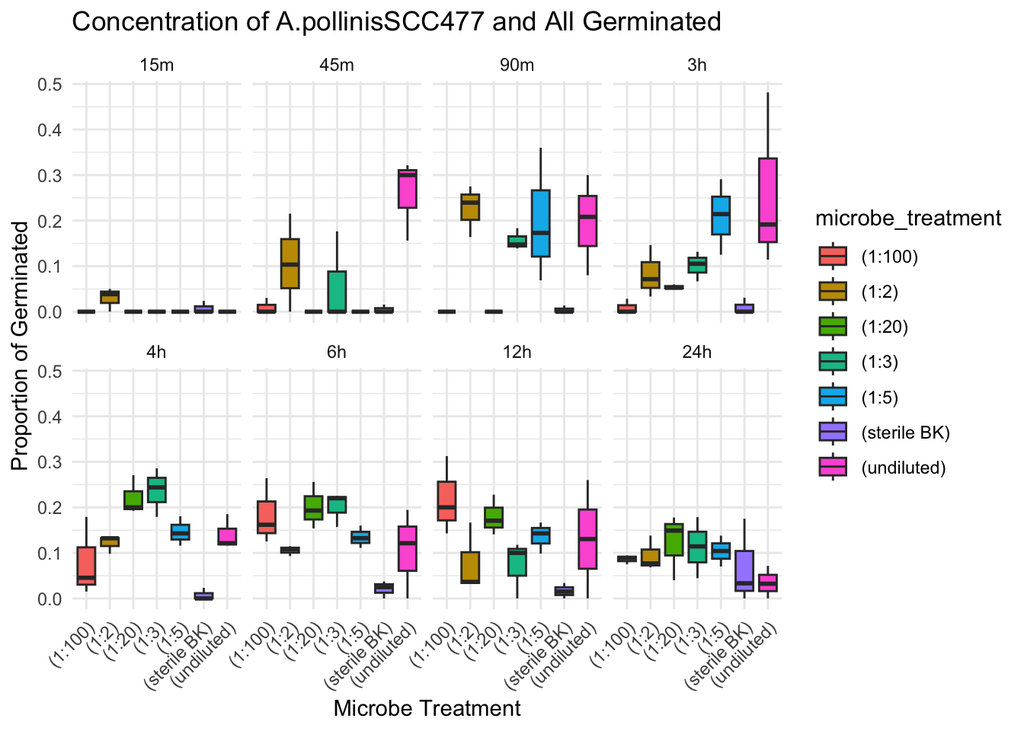

```r
dose_dependence %>%
  mutate(timepoint=factor(timepoint,
         levels=c("15m","45m","90m","3h","4h","6h","12h","24h")))%>%
  ggplot(aes(x=microbe_treatment,
             y=proportion_germinated,
             fill=microbe_treatment))+
  geom_boxplot()+
  facet_wrap(~timepoint, nrow=2)+
  labs(title="Concentration of A.pollinisSCC477 and All Germinated",
       x="Microbe Treatment",
       y="Proportion of Germinated")+
  theme_minimal()+
  theme(axis.text.x=element_text(angle=45, hjust=1))
```

whether treatment accelerates germination.

```r
dose_dependence <- dose_dependence %>%
  mutate(time_minutes=case_when(
    timepoint=="15m" ~ 15,
           timepoint=="45m" ~ 45,
           timepoint=="90m" ~ 90,
           timepoint=="3h"  ~ 180,
           timepoint=="4h"  ~ 240,
           timepoint=="6h"  ~ 360,
           timepoint=="12h" ~ 720,
           timepoint=="24h" ~ 1440))
```

[output not shown]

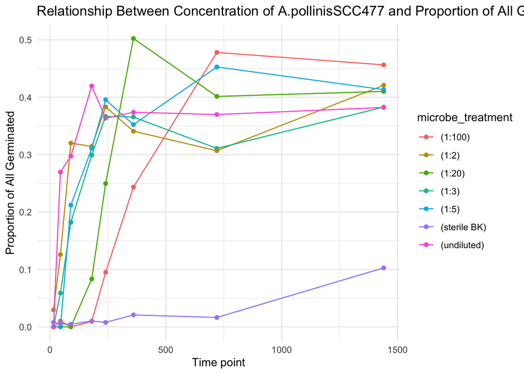

```r
dose_dependence%>%
  group_by(microbe_treatment, time_minutes)%>%
  summarize(mean_germ=mean(allgerm, na.rm=TRUE)) %>%
  ggplot(aes(time_minutes, mean_germ,
             color=microbe_treatment,
             group=microbe_treatment))+
  geom_point()+
  geom_line()+
  labs(
    title="Relationship Between Concentration of A.pollinisSCC477 and Proportion of All Germinated",
    x="Time point",
    y="Proportion of All Germinated")+
  theme_minimal()
```

graph of microbe treatment vs. burst.

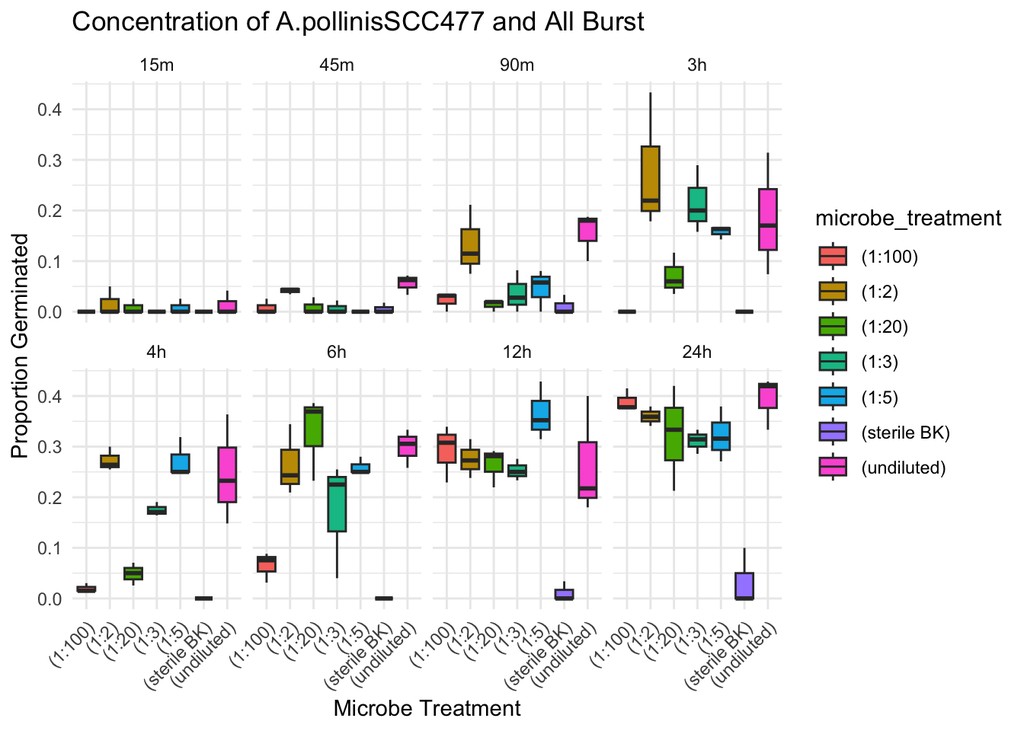

```r
dose_dependence%>%
  mutate(timepoint=factor(timepoint,
         levels=c("15m","45m","90m","3h","4h","6h","12h","24h")))%>%
  ggplot(aes(x=microbe_treatment,
             y=allburst,
             fill=microbe_treatment))+
  geom_boxplot()+
  facet_wrap(~timepoint, nrow=2)+
  theme_minimal()+
  labs(title="Concentration of A.pollinisSCC477 and All Burst",
       x="Microbe Treatment",
       y="Proportion Germinated")+
  theme(axis.text.x=element_text(angle=45, hjust=1))
```